# project4Notebook_ExploratoryAnalysis_20jun

## ...

### ...

### Look at relationship between age and gender

#### Look at relationship between age and gender at busiest start stations

```python
df_age_busy.member_gender.value_counts()
```

```
Male      128156
Female     38756
Other       1461
Name: member_gender, dtype: int64
```

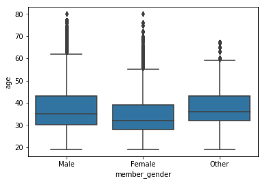

```python
base_color = sb.color_palette()[0]
sb.boxplot(x='member_gender', y='age', data=df_age_busy, color=base_color);
```

#### Comments

- Age by counts is dissimilar across the plots, with males having the greatest concentration by far.
- All genders show a common concentration of ages 32 to 40.
- Median age range: between 32 and 35 years
- Median age by gender at the busiest start stations fall within an 4 year range.
- Those who rent bikes at the busiest start stations have a similar range of ages.
- Males range in age from 30 to 43, with a median age of 35.

## ...

#### Look at relationship between age and gender at least busiest start stations

```python
df_age_notBusy.member_gender.value_counts()
```

```
Male      251
Female     68
Other       9
Name: member_gender, dtype: int64
```

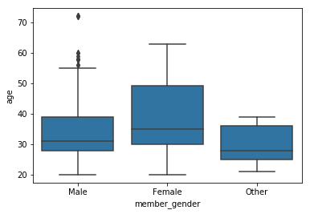

```python
base_color = sb.color_palette()[0]
sb.boxplot(x='member_gender', y='age', data=df_age_notBusy, color=base_color);
```

## ...

### Look at relationship between age and day rental began

#### Look at relationship between age and day rental began at busiest start stations

```python
df_age_busy.day_started.value_counts()
```

```
1    32409
2    31618
3    31273
0    29430
4    27272
5     9061
6     7310
Name: day_started, dtype: int64
```

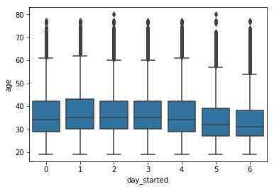

```python
base_color = sb.color_palette()[0]
sb.boxplot(x='day_started', y='age', data=df_age_busy, color=base_color);
```

#### Comment

- Median age for weekdays, about 34, is similar for weekends, about 32.5.
- Age for weekend rentals trends lower.
- Note: weekend rental counts are at least 1/3 lower than weekdays (ref: value_counts).

#### Look at age and day_started for least busiest start stations

```python
df_age_notBusy.day_started.value_counts()
```

```
3    59
6    57
2    50
0    47
4    43
5    36
1    36
Name: day_started, dtype: int64
```

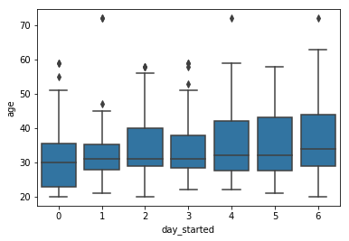

```python
base_color = sb.color_palette()[0]
sb.boxplot(x='day_started', y='age', data=df_age_notBusy, color=base_color)
```

#### Comment

- Median age for all days ranges between 30 and 33
- Rental counts are closely ranged: 36 to 59

## ...

### Look at age and duration of rental

#### First, compare age and rental duration at busiest and least busiest start stations: side by side

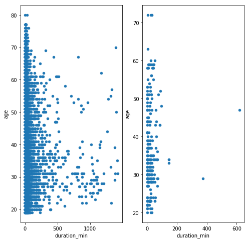

```python
fig, ax = plt.subplots(ncols=2, figsize = [8,8])

df_age_busy.plot( x='duration_min', y='age', kind='scatter', ax=ax[0]);

df_age_notBusy.plot( x='duration_min', kind='scatter', y='age', ax=ax[1]);
```

#### Comment

- Even with a difference in x scales the distribution of points shows fewer counts for longer rides in both busiest and least busiest stations as was shown in the univariate plots.
- Age does not seem to be a limiting factor for either station type.

#### Look now at stats and plot for busiest start station

```python
# Look at duration_min stats and ranges for df_notBusy
df_age_busy.duration_min.describe()
```

```
count    168373.000000
mean         12.190482
std          28.796525
min           1.000000
25%           6.000000
50%           9.000000
75%          13.000000
max        1421.000000
Name: duration_min, dtype: float64
```

```python
df_age_busy.age.describe()
```

```
count    168373.000000
mean         36.578068
std          10.211787
min          19.000000
25%          29.000000
50%          34.000000
75%          42.000000
max          80.000000
Name: age, dtype: float64
```

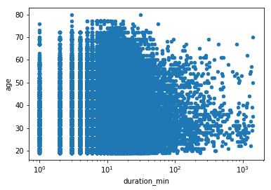

```python
# Use log transformation to make data readable


df_age_busy.plot( x='duration_min', y='age', kind='scatter');
plt.xscale('log');
```

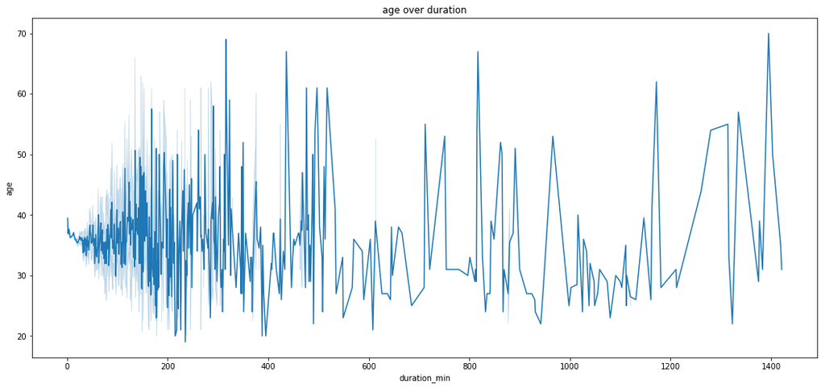

```python
plt.figure(figsize=(18, 8))
sb.lineplot(x="duration_min", y="age", data=df_age_busy ).set_title('age over duration')
plt.show()
```

#### Comment

- The stats are confirmed by the plots: 75% of renters are age 42 and lower and 75% of rental durations are 13 minutes and lower.
- Ages 25 to 45 appear to have the most activity.

### ...

#### Finally, look at stats and plot for least busiest start station

```python
# Look at duration_min stats and ranges for df_notBusy
df_notBusy.duration_min.describe()
```

```
count    353.000000
mean      26.934844
std       65.110385
min        1.000000
25%        5.000000
50%       17.000000
75%       30.000000
max      937.000000
Name: duration_min, dtype: float64
```

```python
df_notBusy.age.describe()
```

```
count    353.000000
mean      32.611898
std       13.984755
min        0.000000
25%       24.000000
50%       31.000000
75%       39.000000
max       72.000000
Name: age, dtype: float64
```

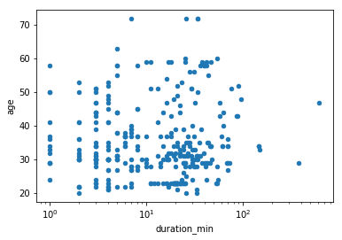

```python
df_age_notBusy.plot( x='duration_min', kind='scatter', y='age');
plt.xscale('log');
```

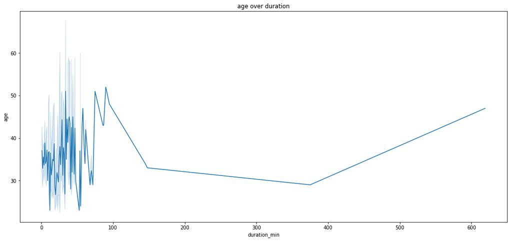

```python
plt.figure(figsize=(18, 8))
sb.lineplot(x="duration_min", y="age", data=df_age_notBusy ).set_title('age over duration')
plt.show()
```

#### Comment

- The stats for least busiest station are also confirmed by the plots: 75% of renters are age 39 and lower and 75% of rental durations are 30 minutes and lower.
- Ages 30 to 40 appear to have the most activity.

## ...

## Comparisons with age completed.

### Use age group (ages 14 -80) subset dataframes of df_busy and df_not busy for comparisons with all characteristics: df_age_busy and df_age_notBusy

## Next: Comparisons with user_type.

### ...

### Look at user_type and member_gender for busiest and least busiest start stations

### ...

#### Look at user_type and member_gender for busiest start stations (df_age_busy)

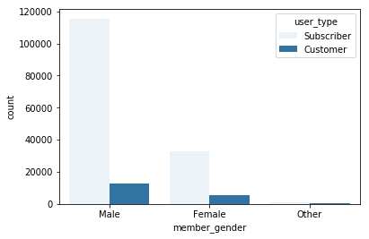

```python
# Look at user type and member_gender using df_busy dataframe

base_color = sb.color_palette()[0]
sb.countplot(x='member_gender',hue='user_type', data=df_age_busy, color=base_color);
```

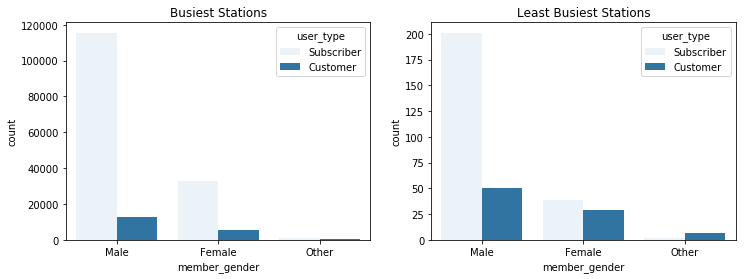

```python
fig, ax = plt.subplots(ncols=2, figsize = [12,4])

base_color = sb.color_palette()[0]
sb.countplot(x='member_gender',hue='user_type', data=df_age_busy, color=base_color, ax=ax[0]).set_title('Busiest Stations');

sb.countplot(x='member_gender',hue='user_type', data=df_age_notBusy, color=base_color, ax=ax[1]).set_title('Least Busiest Stations');
```

#### Comment

- Busiest: male subscribers far outcount females and others.
- Least busiest: male subscribers also far outcount females and others.

### Comparing user_type and member_gender:

- For busiest and least busiest start stations male subscribers far outcount females and others.

### ...

### Look at user_type and day_started for busiest and least busiest start stations

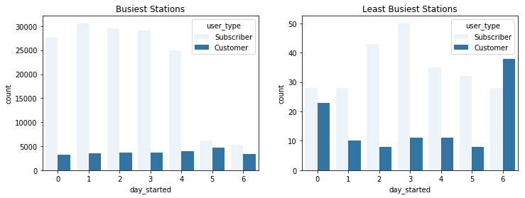

```python
# Look at user_type and day rental started
fig, ax = plt.subplots(ncols=2, figsize = [12,4])

base_color = sb.color_palette()[0]
sb.countplot(x='day_started',hue='user_type', data=df_busy, color=base_color, ax=ax[0]).set_title('Busiest Stations');

sb.countplot(x='day_started',hue='user_type', data=df_notBusy, color=base_color, ax=ax[1]).set_title('Least Busiest Stations');
```

### Comparing user_type and day of rental:

- There does not seem to be any basis for comparison when looking at the plots for busiest and least busiest start stations.
- However, it is apparent that there is a significant difference in usage of the start stations.

### ...

### Look at user_type and duration of rental for busiest and least busiest start stations

#### Look at user_type and duration of rental for busiest start stations

#### Use log transformation to clarify lower ranges

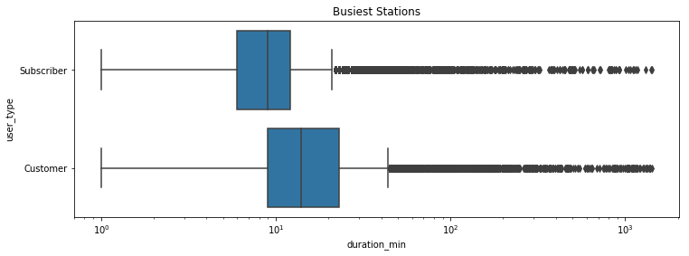

```python
# Look at user_type and duration of rental for busiest start stations
fig, ax = plt.subplots(nrows=0, figsize = [12,4])
base_color = sb.color_palette()[0]

sb.boxplot(x='duration_min', y='user_type', data=df_age_busy, color=base_color).set_title('Busiest Stations')
plt.xscale('log');
```

#### Comment

- Subscribers rent for shorter durations than do customers.
- Subscribers have more outliers of rental periods.

#### Look at user_type and duration of rental for least busiest start stations

#### Use log transformation to clarify lower ranges

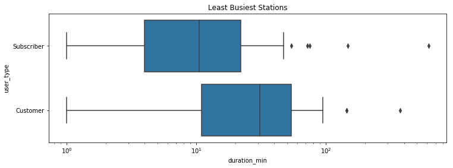

```python
# Look at user_type and duration of rental for busiest start stations
fig, ax = plt.subplots(nrows=0, figsize = [12,4])
base_color = sb.color_palette()[0]
sb.boxplot(x='duration_min', y='user_type', data=df_age_notBusy, color=base_color).set_title('Least Busiest Stations')
plt.xscale('log');
```

#### Comment

- Subscribers rent for shorter periods than do customers.
- Customers have a longer whisker for shorter trips.

### Comparing user_type and duration of rental characteristics for busiest and least busiest start stations:

- For both busiest and least busiest start stations subscribers rent for shorters periods than do customers.

### ...

## Comparisons with user_type completed. Next: Comparisons with member_gender.

## ...

### Look at gender and day_started for busiest and least busiest start stations

#### Look at gender and day_started for busiest and least busiest start stations

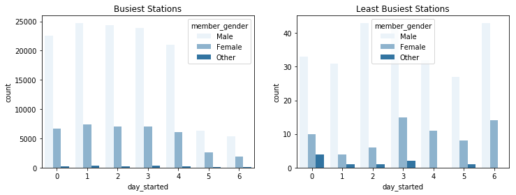

```python
fig, ax = plt.subplots(ncols=2, figsize = [12,4])

base_color = sb.color_palette()[0]
sb.countplot(x='day_started',hue='member_gender', data=df_age_busy, color=base_color, ax=ax[0]).set_title('Busiest Stations');

#base_color = sb.color_palette()[0]
sb.countplot(x='day_started',hue='member_gender', data=df_age_notBusy, color=base_color, ax=ax[1]).set_title('Least Busiest Stations');
```

### Comparing member_gender and day_started characteristics for busiest and least busiest start stations:

- For both busiest and least busiest start stations males comprise the largest group for each day.
- Weekdays are the heaviest start days for male renters at the busiest start stations.

## ...

### Look at gender and day_started duration of rental for busiest and least busiest start stations

#### Look at gender and day_started duration of rental for busiest start stations

#### Use log transformation to clarify lower ranges

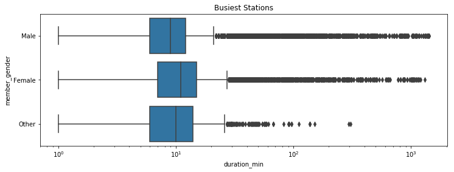

```python
# Look at gender and day_started duration of rental for busiest start stations

fig, ax = plt.subplots(nrows=0, figsize = [12,4])
base_color = sb.color_palette()[0]
sb.boxplot(x='duration_min', y='member_gender', data=df_age_busy, color=base_color).set_title('Busiest Stations')
plt.xscale('log');
```

#### Comment

- The medians are very similar for all genders, with that for males slightly lower.
- There is clearly a very similar concentration of rental periods for all genders.T
- Others have fewest outliers.

#### Look at gender and day_started duration of rental for least busiest start stations

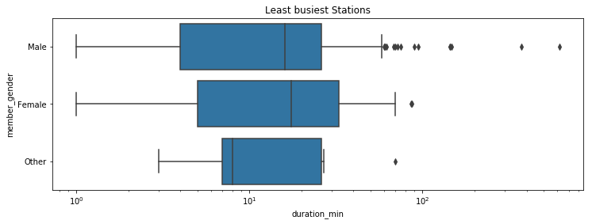

```python
# Look at gender and day_started duration of rental for least busiest start stations

fig, ax = plt.subplots(nrows=0, figsize = [12,4])
base_color = sb.color_palette()[0]
sb.boxplot(x='duration_min', y='member_gender', data=df_age_notBusy, color=base_color).set_title('Least busiest Stations')
plt.xscale('log');
```

#### Comment

- Unlike at the busiest stations, there is a marked difference in medians, with Others having lower medians for duration rental periods.
- Each gender group has a distinct concentration block of rental periods.
- Males have the most outliers.

### Comparing member_gender and duration of rental characteristics for busiest and least busiest start stations:

- For the busiest stations there is a similarity across the genders for concentration of rental periods and for the mean duration in minutes. This is not duplicated for the least busiest stations.

### ...

## Comparisons with member_gender completed. Next: Comparisons with day_started.

## ...

#### Look at day_started and duration_min for busiest start stations

#### Use log transformation to clarify lower ranges

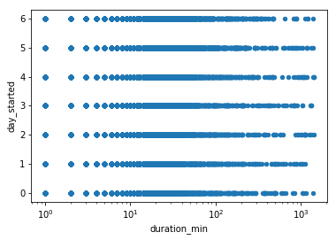

```python
df_age_busy.plot( x='duration_min', y='day_started', kind='scatter');
plt.xscale('log');
```

#### Comment

- Nothing jumps out as being different in this plot. Each day's 'scatter' is similar.

### ...

#### Look at day_started and duration_min for least busiest start station

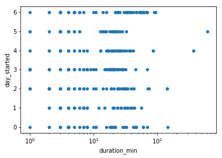

```python
#### Look at day_started and duration_min
df_age_notBusy.plot( x='duration_min', y='day_started', kind='scatter');
plt.xscale('log');
```

### ...

## End Bivariate Exploration

### Discussion

#### Main focus of interest

My primary interest is in characterizing those who use the busiest 5 start_stations and on what days. A secondary interest is learning if the characteristics of busiest and least busiest stations vary.

### Some of the relationships observed in this part of the investigation.

My focus centered on comparing characteristics of those who use the 5 busiest and 5 least busiest start stations. To accomplish this I created subsets of the original dataframe (12 months of activity) and isolated the 5 busiest, as df_busy, and the 5 least busy, as df_notBusy.

The bivariate exploration, then, was carried out using these two dataframe subsets. The most interesting relationships found centered on the user type and gender of the renter. For both subsets, busiest and least busiest, subscribers were the majority of renters. When compared to gender it was confirmed that male subscribers comprised the majority. Boxplots helped to clarify the corresponding medians, outliers and concentrations of activity when comparing age/gender and age/user type. Also, there is a commonality of age groupings when comparing these characteristics.

The characteristic for duration of rental period proved interesting but did not seem to be relevant. The measure is in minutes and it cannot be determined if, for example, the rider stopped off for a coffee along the way and so the bike sat riderless for 30 minutes.

### Other interesting relationships

Throughout the plots it was clear that the busiest and least busiest start stations had varying similarities. Where there are plot consistencies for most characteristics relating to the busiest stations, there are none for these least busiest: user_type and day of rental, age and duration of rental. Because the least busiest stations have such little rental traffic it is interesting to note that there are indeed similarities.

### Questions from bivariate exploration

- Does 'age' need to be narrowed in range in visualizations with other characteristics?  
  **Answer**: yes. A subset was created and used for all comparisons with the age characteristic. Age included: 14 to 80.
- Which user_types ride on which days?  
  **Answer**: subscribers. For both busiest and least busiest start stations the subscribers outnumbered the customers. Weekdays at the busiest stations showed the greatest differences.
- Males comprise the majority of renters at both busiest and least busiest start stations. Are there days when that isn't the case?  
  **Answer**: males do comprise the majority of rentals on every day of the week.
- How does day of the rental impact gender use?  
  **Answer**: gender seems unaffected by day of the week at the busiest stations. Each type shows a proportionate chance from weekday to weekend. At the least busiest stations there is no pattern to reflect on.

### Questions for multivariate exploration

What are the characteristics of those who use the busiest and least busiest start stations? To pin this down, take a multivariate look at how the categorical values of user types and gender are related with age and rental days.

- Will younger, male, subscribers be the majority of renters at both busiest and least busiest start stations?
- Are weekdays busier rental days?
- Is Monday the busiest rental day?
- How do rental characteristics differ for the least busiest start station?
- What is the profile of a typical busiest start station rental?
- What is the profile of a typical least busiest start station rental?

## Multivariate exploration

## Process:

Using subsets of the original dataset, explore user characteristics within age parameters, 14-80,for the 5 busiest start stations, df_age_busy, and 5 least busiest start stations, df_age_notBusy

#### Characteristics to explore further in the multivariate explorations: age, user_type, member_gender, day_started

- Categorical values: user_type, member_gender
- Numerical values: age, day_started ## ...

### Look at the relationships of categorical and numeric characteristics

### PairGrid plots

```python
# Create function for sb PairGrid plot
# Ref: Class Ref: example diamond project, seaborn's PairGrid

categoric_vars = 'member_gender', 'user_type'


def boxgrid(x, y, **kwargs):

    default_color = sb.color_palette()[0]
    sb.boxplot(x, y, color = default_color)
```

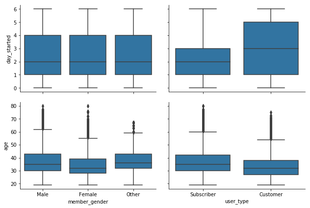

```python
# Plot categoric values with numeric for busiest start stations

plt.figure(figsize = [10, 10])

g = sb.PairGrid(data = df_age_busy, y_vars = ['day_started', 'age'], x_vars= categoric_vars, height=3, aspect = 1.5)

g.map(boxgrid)
plt.show();
```

#### Comment: Busiest Start Stations

These pairGrid visualizations tell a story about users of the busiest stations but need clarification:

#### This information does not sufficiently describe user characteristics. Since it does not include counts the plots tend to be misleading.

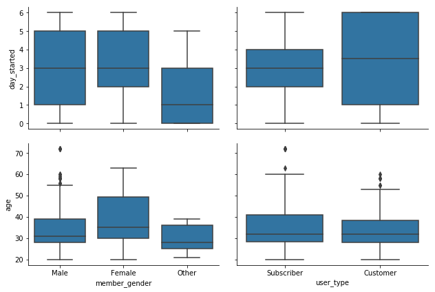

```python
# Plot categoric values against numeric for leasst busiest start stations

g = sb.PairGrid(data = df_age_notBusy, y_vars = ['day_started', 'age'], x_vars= categoric_vars, height=3, aspect = 1.5)
g.map(boxgrid)
plt.show();
```

#### Comment: Least Busiest Start Stations

These pairGrid visualizations tell a story about users of the least busiest stations. It also needs clarification:

#### Just as noted above for the busiest start stations, this information does not sufficiently describe user characteristics. Since it does not include counts the plots tend to be misleading.

## ...

### Furthering the exploration, a look at data presented in boxplots.

#### Following: side by side views of member_gender and user_types shown by day_started -- for busiest and least busiest start stations

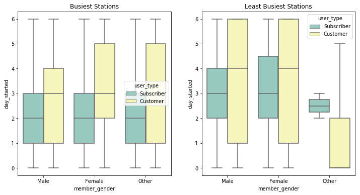

```python
# Use boxplots to further investigate relationships
# Look at plots for categorical values and day_started for busiest and least busiest stations
fig, ax = plt.subplots(ncols=2, figsize = [12,6])
sb.boxplot(data=df_age_busy, x='member_gender', y='day_started', hue='user_type', palette='Set3', ax=ax[0]).set_title('Busiest Stations')
sb.boxplot(data=df_age_notBusy, x='member_gender', y='day_started', hue='user_type', palette='Set3', ax=ax[1]).set_title('Least Busiest Stations');
```

#### Comment: busiest and least busiest start stations

These boxplots offer a better comparison of characteristics than pairGrid plots. Note that counts are not included. Instead plots show rental info: medians, top line of box for 75% and height of box for 50%.

- Busiest start stations: genders who are subscribers are similar in median and distribution over weekdays Tuesday through Thursday. From previous explorations (see next plots) it is known that Monday is a lighter rental day as are Saturday and Sunday. 75% of all subscriber rentals take place Monday through Thursday, for all genders. Medians for user_type are identical with more females customers renting Wednesday through Saturday. Other gender customers have a wider distribution over Monday through Saturday.
- Least busiest start stations: there is an obvious difference between usage of the station types. The only similarities noted for least busy start stations are the medians for male and female subscribers (fall at Thursdays)and the medians for male and female customers (fall at Fridays). Male and female customers have a wider distribution (Tuesdays through Sundays) where others, both customers and subscribers, are shown to have more limited distributions.

## ...

### Following: countplots, counts for member_gender by day_started

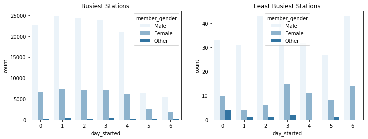

```python
# Look at user_type, member_gender and day rental started
fig, ax = plt.subplots(ncols=2, figsize = [12,4])

base_color = sb.color_palette()[0]
sb.countplot(x='day_started',hue='member_gender', data=df_busy, color=base_color, ax=ax[0]).set_title('Busiest Stations');

sb.countplot(x='day_started',hue='member_gender', data=df_notBusy, color=base_color, ax=ax[1]).set_title('Least Busiest Stations');
```

#### These countplots show counts that further clarify relationships.

- Males clearly outnumber other genders for busiest and least busiest start stations on every day of the week. Note that Monday is NOT the busiest rental day in either plot.

### Following: side by side views of member_gender and user_types shown by age -- for busiest and least busiest start stations

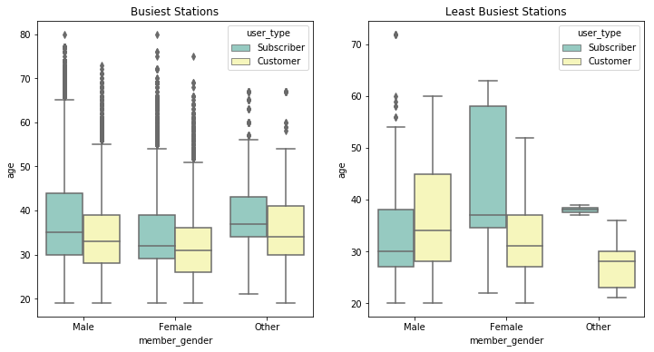

```python
# Look at plots for categorical values and age for busiest and least busiest stations
fig, ax = plt.subplots(ncols=2, figsize = [12,6])
sb.boxplot(data=df_age_busy, x='member_gender', y='age', hue='user_type', palette='Set3',notch=False, ax=ax[0]).set_title('Busiest Stations')
sb.boxplot(data=df_age_notBusy, x='member_gender', y='age', hue='user_type', palette='Set3', notch=False, ax=ax[1]).set_title('Least Busiest Stations');
```

#### Comment: busiest and least busiest start stations

These boxplots offer a better comparison of characteristics than pairGrid plots

- Busiest start stations: Ages of renters fall between 28 and 44, for males it is 30 to 44. Younger males do make up the majority of renters; this is more easily seen in the next plot. Interestingly there is a distribution consistency for all genders, subscribers as well as customers.
- Least busiest start stations: Just as for the comparison with day_started, this plot also shows varying levels of medians and distributions with other subscribers comprising the most compact.Younger males do comprise the majority of male subscriber renters with 75% below the age of 38. Counts provided in a following chart will confirm this for younger males. For male customers the distribution is broader and 75% are below the age of 45.

## ...

### Folowing: countplots, counts for member_gender by age

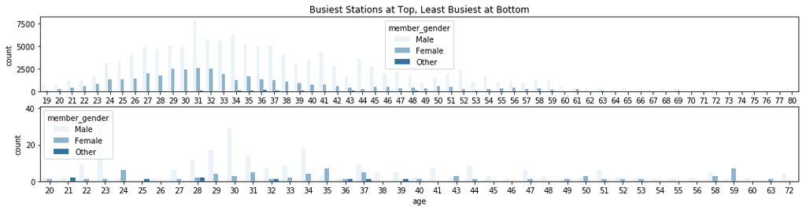

```python
# Look at user_type, member_gender and age
fig, ax = plt.subplots(nrows=2, figsize = [18,4])

base_color = sb.color_palette()[0]
sb.countplot(x='age',hue='member_gender', data=df_age_busy, color=base_color, ax=ax[0]).set_title('Busiest Stations at Top, Least Busiest at Bottom');


sb.countplot(x='age',hue='member_gender', data=df_age_notBusy, color=base_color, ax=ax[1]);
```

### Look at another comparison of categorical and numeric value: catplot

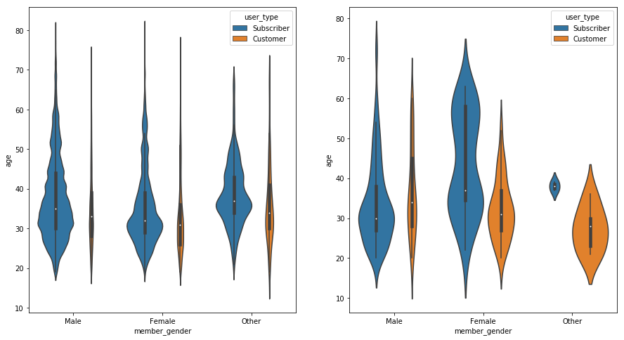

```python
fig, ax = plt.subplots(ncols=2, figsize = [15,8])
#plt.figure(figsize = [10, 10])
sb.catplot(data=df_age_busy, x='member_gender', y='age',ax=ax[0], hue='user_type', kind="violin", aspect=2, scale='count');

sb.catplot(data=df_age_notBusy, x='member_gender', y='age',ax=ax[1], hue='user_type', kind="violin", aspect=2, scale='count');

plt.close(2)
plt.close(3)
```

#### Comment:

These violin plots provide a better clarification than the boxplot and pairGrid plot as it includes the boxplot as well as an underlying distribution. Note gender counts for the busiest start station is larger (168,373). As the rental counts for least busiest stations is small (328) the plot shows distributions and does not represent true counts and may be 'misleadingly smooth'. ( Ref:1)value_counts in following cells;2) https://seaborn.pydata.org/generated/seaborn.violinplot.html?highlight=violinplot#seaborn.violinplot )

```python
df_age_notBusy.start_station_id.value_counts()
```

```
234.0    162
359.0     89
358.0     48
374.0     21
48.0       8
Name: start_station_id, dtype: int64
```

```python
df_age_busy.start_station_id.value_counts()
```

```
67.0    36010
30.0    33571
58.0    33247
15.0    33187
81.0    32358
Name: start_station_id, dtype: int64
```

```python
df_age_notBusy.member_gender.value_counts() # n= 328
```

```
Male      251
Female     68
Other       9
Name: member_gender, dtype: int64
```

```python
df_age_busy.member_gender.value_counts() # n= 168373
```

```
Male      128156
Female     38756
Other       1461
Name: member_gender, dtype: int64
```

```python
df_age_notBusy.user_type.value_counts() # n= 328 = member_gender
```

```
Subscriber    242
Customer       86
Name: user_type, dtype: int64
```

```python
df_age_busy.user_type.value_counts() # n= 168373 = member_gender
```

```
Subscriber    149795
Customer       18578
Name: user_type, dtype: int64
```

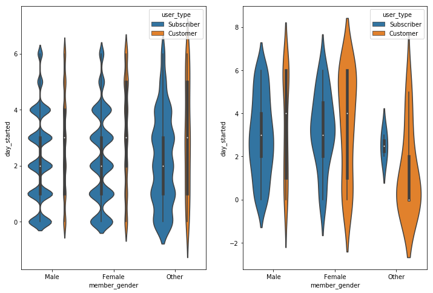

```python
fig, ax = plt.subplots(ncols=2, figsize = [12,8])
#plt.figure(figsize = [10, 10])
sb.catplot(data=df_age_busy, x='member_gender', y='day_started',ax=ax[0], hue='user_type', kind="violin", aspect=2, scale='count');
sb.catplot(data=df_age_notBusy, x='member_gender', y='day_started',ax=ax[1], hue='user_type', kind="violin", aspect=2, scale='count');
plt.close(2)
plt.close(3)
```

## ...

### **References:**

- Project Examples, Class Notes
- https://matplotlib.org/api/_as_gen/matplotlib.pyplot.plot.html#matplotlib.pyplot.plot
- https://matplotlib.org/tutorials/
- https://seaborn.pydata.org/
- https://seaborn.pydata.org/tutorial.html
- https://www.youtube.com/watch?v=BhHOdKyFzyQ boxplot
- https://www.youtube.com/watch?v=cLHwwRgny5g violinplot
- Other: StackOverflow exchanges too numerous to list.

## ...

### End of Program

Back to Top